# LHS experiment

I ran some LHS simulations:

- 100 simulated data sets
- For each data set, 50 parameters were sampled based on the true parameters (using slightly wider range than last time). These values were used as starting parameters for fiting
- Based on the best fit, likelihood surface was created
- Nelder-Mead vs BFGS

```r
library(dplyr)
library(fitsir)
library(magrittr) ## for %T>%
library(tidyr)
library(ggplot2); theme_set(theme_bw())
library(gridExtra)
library(emdbook)
load("LHSsim_full.rda")
SIR.logLik <- fitsir:::SIR.logLik
fitsir.optim <- fitsir:::fitsir.optim
incidence = TRUE
```

```r
png("likelihood.png", width = 2560, height = 2560)

par(mfrow = c(10,10), mar = c(0, 0, 0, 0))

lapply(resList, function(x){
    image(x$surface, xaxt = "n", yaxt = "n", bty = "n")
})

dev.off()
```

This is what the likelihood surface looks like when we fix $\gamma, N$ and vary 2 other parameters.

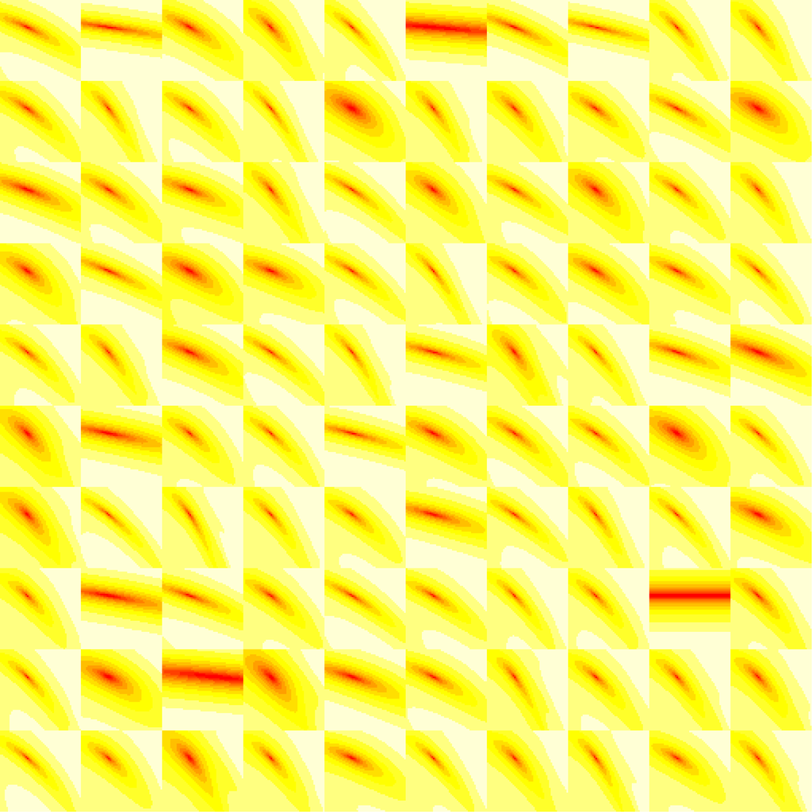

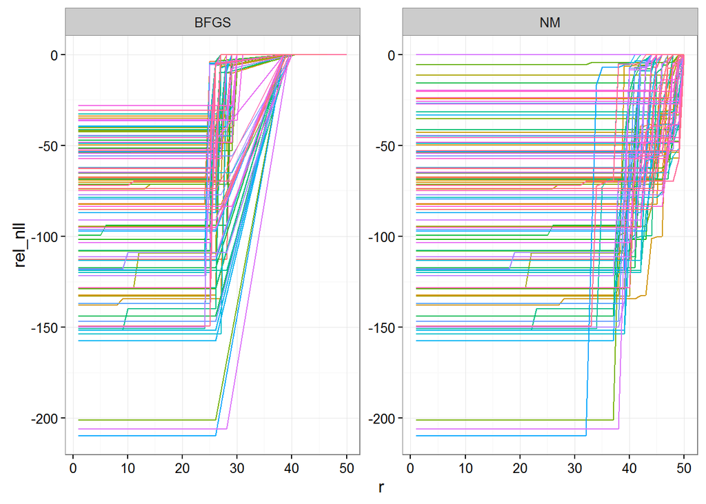

```r
## would like to do this as a "functional sequence" if we can figure it out
L_sum <-  . %>%
    lapply(function(x) data.frame(ll=x$fitted2$ll)) %>%
    bind_rows(.id="run") %>%
    group_by(run) %>%
    mutate(r=rank(-ll),
           rel_nll=(min(ll, na.rm = TRUE)-ll)) ## there's one fit in BFGS that gives NA...

L_comb <- list(NM=L_sum(resList),BFGS=L_sum(resList.grad)) %>%
    bind_rows(.id="optim")

ggplot(L_comb,aes(r,rel_nll,group=run,colour=run))+geom_line()+
    facet_wrap(~optim,scale="free") +
    theme(
        legend.position = "none"
    )
```

Summary:

```
## Source: local data frame [200 x 4]
## Groups: run [?]
##
##      run optim     n       diff
##    <chr> <chr> <int>      <dbl>
## 1      1  BFGS    22 -112.65380
## 2      1    NM    10 -112.65345
## 3     10  BFGS    25  -62.80287
## 4     10    NM     5  -62.79957
## 5    100  BFGS    24  -67.49503
## 6    100    NM     6  -67.48947
## 7     11  BFGS    24  -68.04132
## 8     11    NM     6  -68.04015
## 9     12  BFGS    26  -82.18032
## 10    12    NM     9  -82.17879
## # ... with 190 more rows
```

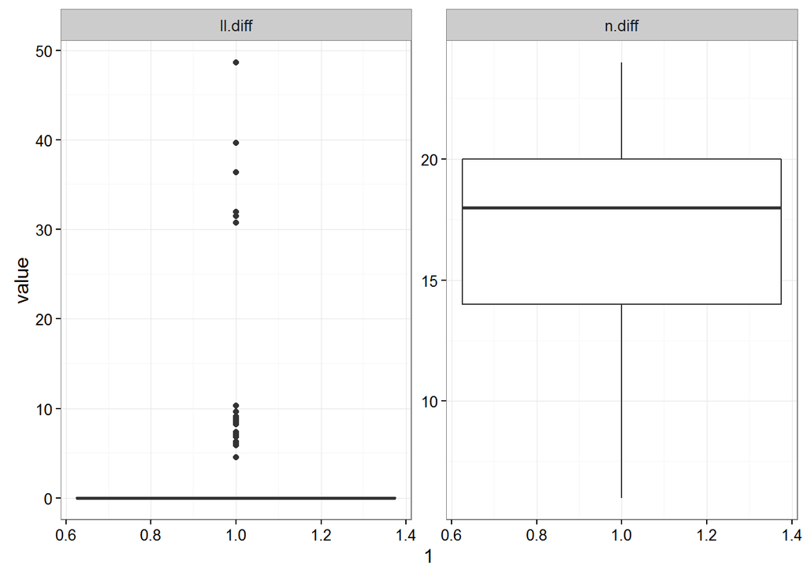

```r
## ??? summarise: what fraction are bad, and how much worse is bad
## than best ??
## for each run: fraction that are good (e.g. 40/50) and the
##   difference between top and bottom; the only trick is deciding
##   how big the threshold between good an bad is (e.g. >10 units worse
##   than good = bad

sum_comb <- L_comb %>%
    group_by(run, optim) %>%
    ## ll > 1.01 * max(ll) for number of good fits
    summarize(n = sum(ll < 1.01 * max(ll)), diff = min(ll) - max(ll))

## visualizing BFGS vs NM?

sum_comb %T>%
    print %>%
    summarize(n.diff = -diff(n), ll.diff = diff(diff)) %>%
    gather(key, value, -run) %>%
    ggplot() +
        geom_boxplot(aes(x = 1, y = value)) +
    facet_wrap(~key, scale = "free")
```

What this tells us is that NM always has less bad fits compared to BFGS, and they both have similar differences in maxiumum/minimum likelihood (BFGS gives wider range of parameters and give bad fits more often but they don’t have worse log-likelihood compared to the bad fits given by NM).